# Albert Einstein - DS Test in R

Caio Serrano

9/29/2019

## Visualizing the problem - Data Analysis - Part 1: Structure

First of all, we need understand what kind of problem and data we going to handle. Here are the data structure:

```r
df_points <- read.delim("df_points.txt", row.names=1, quote="", stringsAsFactors=FALSE)
summary(df_points)
```

```
##        x                   y                  z
##  Min.   :-499.8023   Min.   :-499.899   Min.   :-499.953
##  1st Qu.:-249.1999   1st Qu.:-248.955   1st Qu.:-258.006
##  Median :   3.6635   Median :  -5.446   Median :  -8.221
##  Mean   :   0.8504   Mean   :  -3.109   Mean   :  -2.601
##  3rd Qu.: 248.8800   3rd Qu.: 244.396   3rd Qu.: 252.930
##  Max.   : 499.8725   Max.   : 499.752   Max.   : 499.872
##      label
##  Min.   :0.0000
##  1st Qu.:0.0000
##  Median :1.0000
##  Mean   :0.5027
##  3rd Qu.:1.0000
##  Max.   :1.0000
```

```r
str(df_points)
```

```
## 'data.frame':    10000 obs. of  4 variables:
##  $ x    : num  326 -314 -328 -149 -467 ...
##  $ y    : num  189 307 182 147 250 ...
##  $ z    : num  -312.2 -179 446.3 -27.5 -306.5 ...
##  $ label: num  0 1 1 1 1 1 1 1 0 0 ...
```

## Visualizing the problem - Data Analysis - Part 2: Check normalization

Before create models to fit our data, we need to know if our data is normalized, in another others, if our data is in a good format for model:

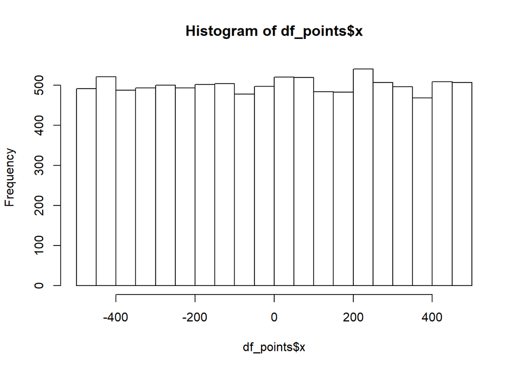

```r
hist(df_points$x)
```

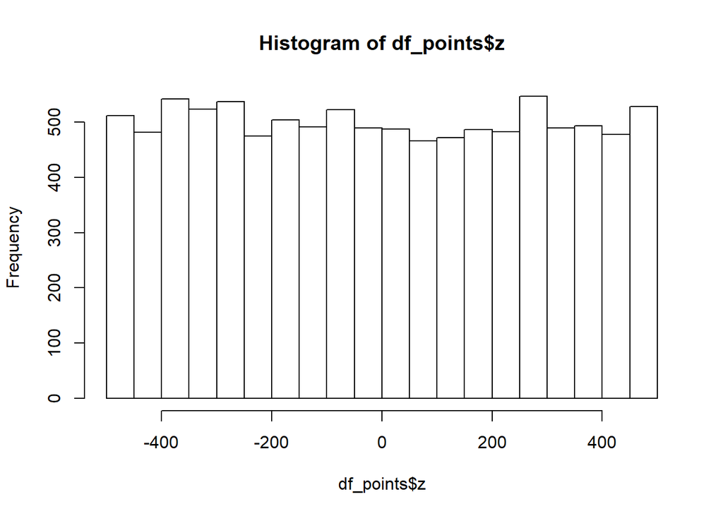

```r
hist(df_points$z)
```

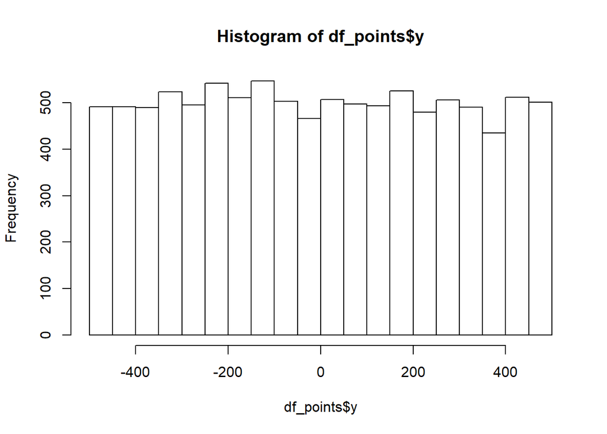

```r
hist(df_points$y)
```

As we can see, our data isn’t normalize as we want. We need to normalize our data.

```r
df_points$x <- scale(df_points$x)
df_points$z <- scale(df_points$z)
df_points$y <- scale(df_points$y)
df_points$label <- as.factor(df_points$label)
```

Now we are good to go with our data. As we can see, we are good to go with our data.

## Split Data - Part 3: split data in test and train datasets

Now, before we start the model fit, we need to split our main dataset in 2 components, as we handling with a classification problem:

```r
set.seed(10)
sample = sample.split(df_points, SplitRatio = .70)
train = subset(df_points, sample == TRUE)
test  = subset(df_points, sample == FALSE)
```

As we can see, the Dataset structure of our train and test still the same:

```r
str(train)
```

```
## 'data.frame':    5000 obs. of  4 variables:
##  $ x    : num [1:5000, 1] -1.09279 -1.14106 -0.0857 0.00975 1.18804 ...
##  $ y    : num [1:5000, 1] 1.081 0.643 -0.143 -0.869 0.509 ...
##  $ z    : num [1:5000, 1] -0.6076 1.5459 -0.9443 -1.5237 0.0453 ...
##  $ label: Factor w/ 2 levels "0","1": 2 2 2 2 1 1 1 1 1 1 ...
```

```r
str(test)
```

```
## 'data.frame':    5000 obs. of  4 variables:
##  $ x    : num [1:5000, 1] 1.129 -0.518 -1.623 1.403 -1.625 ...
##  $ y    : num [1:5000, 1] 0.669 0.523 0.883 0.445 -0.16 ...
##  $ z    : num [1:5000, 1] -1.0662 -0.0857 -1.0465 1.6699 -1.1621 ...
##  $ label: Factor w/ 2 levels "0","1": 1 2 2 2 1 2 1 2 2 2 ...
```

```r
train$label <- as.factor(train$label)
test$label <- as.factor(test$label)
```

## Time to fit - Part 4 - Logistic Regresion Model

Now is the time we attempt to model our classification problem. Our first try will be the Logistic Regression Algorithm. Here, we can see when the model learn (`glm.fit`) about our data

```r
glm.fit <- glm(label ~ x + y + z, train ,family=binomial(link = "logit"))
```

And now, we can see when the model try to predict the classification using what it learned. Obs: `ifelse` part is necessary because the Logistic Regression Agorithm predict using the probability of be 1 or 0 in our case. On this case, for don’t transform all predicted classification in 0, we need to use the threshold `0.1`

```r
glm.fit <- glm(label ~ x + y + z, train ,family=binomial(link = "logit"))
glm.pred <- predict(glm.fit, newdata = test)
glm.results <- ifelse(glm.pred >= 0.1, 1, 0)
glm.results <- as.factor(glm.results)
```

Now let’s check how good our model really is to predict?

```r
confusionMatrix(glm.results,reference =  test$label)
```

```
## Confusion Matrix and Statistics
##
##           Reference
## Prediction    0    1
##          0 2104 2131
##          1  413  352
##
##                Accuracy : 0.4912
##                  95% CI : (0.4773, 0.5052)
##     No Information Rate : 0.5034
##     P-Value [Acc > NIR] : 0.959
##
##                   Kappa : -0.0224
##
##  Mcnemar's Test P-Value : <2e-16
##
##             Sensitivity : 0.8359
##             Specificity : 0.1418
##          Pos Pred Value : 0.4968
##          Neg Pred Value : 0.4601
##              Prevalence : 0.5034
##          Detection Rate : 0.4208
##    Detection Prevalence : 0.8470
##       Balanced Accuracy : 0.4888
##
##        'Positive' Class : 0
##
```

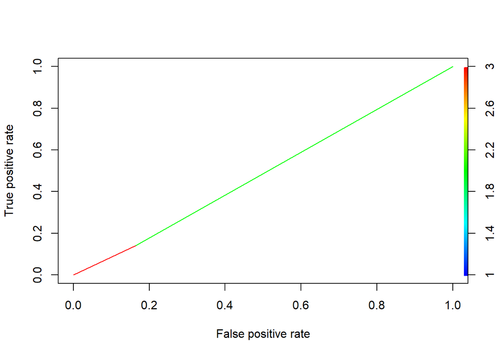

```r
ROC_GLM  <- prediction(as.numeric(glm.results),test$label)
GLM_PERF <- performance(ROC_GLM,"tpr","fpr")
plot(GLM_PERF,colorize = TRUE)
```

## Time to fit - Part 5 - Support Vector Machine (SVM)

Our another try will be with Support Vector Machine Algorithm. It is algorithm that try to classify the data using hyperplanes.

```r
svm.fit <- ksvm(label ~ x + y + z, train, type = 'C-svc', kernel = 'rbfdot')
svm.pred <- predict(svm.fit, test)
```

Now let’s check how good our model really is to predict?

```r
confusionMatrix(as.factor(svm.pred),as.factor(test$label))
```

```
## Confusion Matrix and Statistics
##
##           Reference
## Prediction    0    1
##          0 1990  714
##          1  527 1769
##
##                Accuracy : 0.7518
##                  95% CI : (0.7396, 0.7637)
##     No Information Rate : 0.5034
##     P-Value [Acc > NIR] : < 2.2e-16
##
##                   Kappa : 0.5033
##
##  Mcnemar's Test P-Value : 1.292e-07
##
##             Sensitivity : 0.7906
##             Specificity : 0.7124
##          Pos Pred Value : 0.7359
##          Neg Pred Value : 0.7705
##              Prevalence : 0.5034
##          Detection Rate : 0.3980
##    Detection Prevalence : 0.5408
##       Balanced Accuracy : 0.7515
##
##        'Positive' Class : 0
##
```

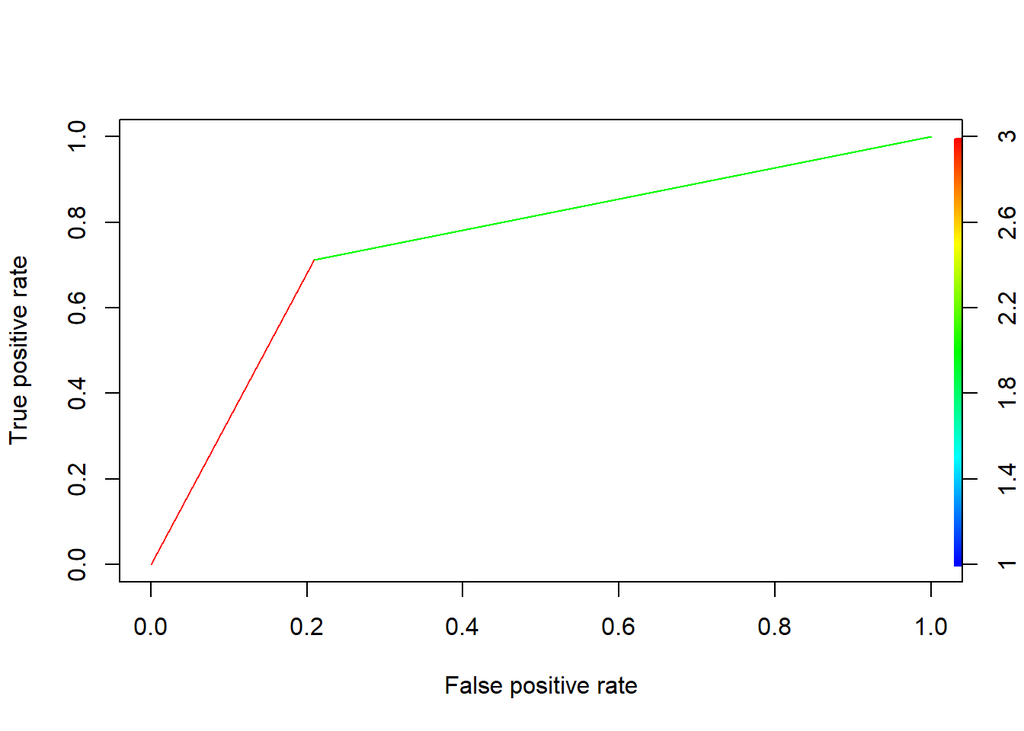

```r
ROC_SVM  <- prediction(as.numeric(svm.pred), as.numeric(test$label))
SVM_PERF <- performance(ROC_SVM,"tpr","fpr")
plot(SVM_PERF,colorize = TRUE)
```

## Conclusion - Part 6

With the both tests made with the SMV and GLM model, we can conclude that SVM showed a better accuracy and positive rate to predict the truth.